# Beyond Failing to Reject: A Bayesian Approach to Evaluating the Andilaye WASH Intervention

Final Project for CSSS 564 (Spring 2026)

Yuwei Wang & William Garcia

2026-06-02

## 1. Research Question & Data

```r
rm(list = ls()) # Clear the workspace
# Standard configuration for the course
knitr::opts_chunk$set(echo = TRUE, warning = FALSE, message = FALSE)

library(tidyverse)
```

```r
library(ggplot2)
library(knitr)
library(kableExtra)
library(rjags)
library(coda)
library(haven)
library(loo)
library(gridExtra)
library(scales)
# 0. Load raw data & select only needed columns upfront -----
f1_cols <- paste0("F_1_", 1:10)
f2_cols <- paste0("F_2_", 1:13)

get_data_dir <- function() {
  candidates <- c(
    file.path(getwd(), "final project"),
    getwd()
  )

  data_dir <- candidates[file.exists(file.path(candidates, "all_hh_members.dta"))][1]

  if (is.na(data_dir)) {
    stop("Could not find all_hh_members.dta. Check your working directory.")
  }

  normalizePath(data_dir, winslash = "/", mustWork = TRUE)
}

data_dir <- get_data_dir()

dta_path <- function(file) {
  file.path(data_dir, file)
}

# From hh_members files: hh_id, Z_1, A_1_13 baseline only, item scores
baseline_hh_members <- read_dta(dta_path("all_hh_members.dta")) %>%
  select(hh_id, Z_1, A_1_13, all_of(c(f1_cols, f2_cols)))

endline_hh_members <- read_dta(dta_path("all_hh_members_end.dta")) %>%
  select(hh_id, Z_1, all_of(c(f1_cols, f2_cols)))

# From hh_lat files: hh_id, Z_1, A_1_13 baseline, A_1_5, A_1_6, rand_var
baseline_hh_lat <- read_dta(dta_path("all_hh_lat.dta")) %>%
  select(hh_id, Z_1, A_1_13, A_1_5, A_1_6, rand_var)

endline_hh_lat <- read_dta(dta_path("all_hh_lat_end.dta")) %>%
  select(hh_id, Z_1, A_1_5, A_1_6, rand_var)

# 1. Helper: score items and aggregate to household-level binary outcomes ----

#    The mental health instrument used in Andilaye is a 23-item adaptation of
#    the Hopkins Symptom Checklist (HSCL), scored 0-3 per item (not 1-4 as in
#    the original HSCL-25). The standard HSCL caseness cutoff is mean >= 1.75
#    on the 1-4 scale, which is equivalent to mean >= 0.75 on the 0-3 scale
#    used here. We apply the scale-corrected threshold (>= 0.75) throughout.

#    Step 1 — filter to completed interviews
#    Step 2 — recode 888/999 to NA
#    Step 3 — compute individual-level subscale means (rowMeans, na.rm)
#    Step 4 — average across household members to one score per household
#    Step 5 — apply caseness threshold >= 0.75 on 0-3 scale

score_outcomes <- function(mem_df, z1_val = 5, a113_filter = FALSE) {

  d <- mem_df %>% filter(Z_1 == z1_val)
  if (a113_filter) d <- d %>% filter(A_1_13 != 0)

  d <- d %>%
    mutate(across(all_of(c(f1_cols, f2_cols)),
                  ~ na_if(na_if(., 888), 999)),
           anxiety_mean    = rowMeans(across(all_of(f1_cols)), na.rm = TRUE),
           depression_mean = rowMeans(across(all_of(f2_cols)), na.rm = TRUE),
           distress_mean   = rowMeans(across(all_of(c(f1_cols, f2_cols))),
                                      na.rm = TRUE))

  d %>%
    group_by(hh_id) %>%
    summarise(
      avg_anxiety_mean    = mean(anxiety_mean,    na.rm = TRUE),
      avg_depression_mean = mean(depression_mean, na.rm = TRUE),
      avg_distress_mean   = mean(distress_mean,   na.rm = TRUE),
      .groups = "drop"
    ) %>%
    mutate(
      anxiety    = if_else(is.nan(avg_anxiety_mean),
                           NA_real_, as.numeric(avg_anxiety_mean    >= 0.75)),
      depression = if_else(is.nan(avg_depression_mean),
                           NA_real_, as.numeric(avg_depression_mean >= 0.75)),
      emotion    = if_else(is.nan(avg_distress_mean),
                           NA_real_, as.numeric(avg_distress_mean   >= 0.75))
    ) %>%
    select(hh_id, anxiety, depression, emotion)
}

# 2. Helper: build the lat-side covariate frame (identifiers + design vars)-----
build_lat <- function(lat_df, z1_val = 5, a113_filter = FALSE) {

  d <- lat_df %>%
    distinct(hh_id, .keep_all = TRUE) %>%
    filter(Z_1 == z1_val)
  if (a113_filter) d <- d %>% filter(A_1_13 != 0)

  d %>%
    mutate(
      treatment = as.integer(rand_var),
      # woreda_id: integer 1:3 passed directly to JAGS as an index
      #   1 = Farta  (reference; gamma[1] <- 0 imposed in JAGS model string)
      #   2 = Fogera
      #   3 = Bahir Dar Zuria
      woreda_id = case_when(
        A_1_5 == 100 ~ 1L,
        A_1_5 == 200 ~ 2L,
        A_1_5 == 300 ~ 3L
      ),
      # Re-index A_1_6 to contiguous 1:50 — required for JAGS
      # (raw A_1_6 has gaps: values up to 58 with only 50 unique levels)
      cluster_id = as.integer(factor(A_1_6))
    ) %>%
    select(hh_id, cluster_id, treatment, woreda_id)
}

# 3. Build endline dataset (primary analysis)
endline_outcomes <- score_outcomes(endline_hh_members, a113_filter = FALSE)
endline_lat      <- build_lat(endline_hh_lat,          a113_filter = FALSE)

endline_clean <- inner_join(endline_outcomes, endline_lat, by = "hh_id")

# 4. Build baseline outcomes (for ANCOVA sensitivity model) ----
baseline_outcomes <- score_outcomes(baseline_hh_members, a113_filter = TRUE) %>%
  rename(anxiety_bl    = anxiety,
         depression_bl = depression,
         emotion_bl    = emotion)

# 5. Build panel dataset: endline + baseline outcomes joined by hh_id
## 4 endline households have no baseline record (Z_1 != 5 at baseline)
## their _bl variables will be NA.
## This is expected and documented.
panel_clean <- endline_clean %>%
  left_join(baseline_outcomes, by = "hh_id")
```

**Research Question**: What is the posterior probability that the Average Predictive Difference (APD) — the average difference in predicted probability of screening positive between intervention and control households — falls within [-0.05, +0.05] for each of the three mental health outcomes? And what is the full posterior distribution of between-cluster variance in mental health outcomes across the 50 kebeles?

## 2. Model Specification

We fit a Bayesian hierarchical logistic regression separately for each of the three binary outcomes (`anxiety`, `depression`, `emotion`). Let $i$ index households ($i = 1, \ldots, N$), $j[i]$ index the kebele cluster for household $i$ ($j = 1, \ldots, 50$), and $w[i] \in \{1, 2, 3\}$ denote the woreda index.

**Likelihood.** Each binary outcome $y_i$ is modeled as:

$$y_i \mid p_i \sim
\text{Bernoulli}(p_i)$$

$$\text{logit}(p_i) = \alpha_{j[i]} +
\beta_{\text{trt}} \cdot x_i^{\text{trt}} + \gamma_{w[i]}$$

where $x_i^{\text{trt}}$ is the binary treatment indicator (1 = intervention, 0 = control), $\alpha_{j[i]}$ is the random intercept for kebele $j[i]$, and $\gamma_{w[i]}$ is the fixed woreda effect. Farta is the reference category, enforced by the constraint $\gamma_1 = 0$.

**Cluster-level random intercepts.** Kebele intercepts are modeled as exchangeable draws from a common Normal distribution:

$$\alpha_j \mid \mu_0,\,
\sigma_{\text{cluster}} \sim \mathcal{N}(\mu_0,\,
\sigma_{\text{cluster}}^2), \quad j = 1, \ldots, 50$$

This partial-pooling structure allows each cluster to have its own baseline log-odds while borrowing information across clusters. Exchangeability is justified by the study design: kebeles were randomly selected and randomly assigned, and there is no a priori reason to expect any particular kebele to differ from the others in ways not already captured by the woreda fixed effects.

**Prior distributions.**

$$\beta_{\text{trt}} \sim \mathcal{N}(0,\,
1^2)$$
$$\gamma_1 = 0, \quad
\gamma_2,\, \gamma_3 \sim \mathcal{N}(0,\, 1^2)$$
$$\mu_0 \sim \mathcal{N}(-1.1,\, 0.5^2)$$
$$\sigma_{\text{cluster}} \sim
\text{Half-}\mathcal{N}(0, 0.5^2)$$

We started with weakly informative priors for all parameters but found that $\mu_0$ and $\sigma_{\text{cluster}}$ did not pass the predictive check with the observed prevalences. So we calibrated them according to the prior predictive check in Section 3, which revealed that a more informative prior on $\mu_0$ centered near the observed prevalences and a more informative half-Normal prior on $\sigma_{\text{cluster}}$ were needed to generate plausible data.

**Primary estimand: Average Predictive Difference (APD).**

$$\widehat{\text{APD}}^{(s)} = \frac{1}{N}
\sum_{i=1}^{N} \left[\text{logit}^{-1}\!\left(\alpha_{j[i]}^{(s)} +
\beta_{\text{trt}}^{(s)} + \gamma_{w[i]}^{(s)}\right) -
\text{logit}^{-1}\!\left(\alpha_{j[i]}^{(s)} +
\gamma_{w[i]}^{(s)}\right)\right]$$

We report the posterior mean, 95% HDI, the posterior probability that $|\widehat{\text{APD}}^{(s)}| < 0.05$ (inside the ROPE $[-0.05,\, +0.05]$), and the reciprocal $1/|\overline{\text{APD}}|$ as the Number Needed to Treat. We also report the posterior distribution of $\sigma_{\text{cluster}}$ and the implied ICC computed draw-by-draw as $\sigma_{\text{cluster}}^{(s)2} / (\sigma_{\text{cluster}}^{(s)2} + \pi^2/3)$.

**ANCOVA.** A second model augments the linear predictor with each household’s baseline caseness status $y_i^{\text{bl}} \in \{0, 1\}$:

$$\text{logit}(p_i) = \alpha_{j[i]} +
\beta_{\text{trt}} \cdot x_i^{\text{trt}} + \gamma_{w[i]} + \delta \cdot
y_i^{\text{bl}}, \quad \delta \sim \mathcal{N}(0,\, 1)$$

Including baseline outcome is causally clean (measured before randomization) and justified on efficiency grounds. The two models are compared via PSIS-LOO on the common subsample of 1,468 households (4 households lack a baseline record). If LOO favors the ANCOVA model by more than 2 SEs in ELPD, we report both sets of APD estimates; otherwise the primary model is preferred on parsimony grounds.

```r
# --- Primary JAGS model string ---
model_string_primary <- "
model {
  for (i in 1:N) {
    y[i] ~ dbern(p[i])
    logit(p[i]) <- alpha[cluster[i]] + beta_trt * trt[i] + gamma[woreda[i]]
  }
  for (j in 1:J) {
    alpha[j] ~ dnorm(mu0, tau_cluster)
  }
  beta_trt      ~ dnorm(0, 1)
  gamma[1]      <- 0
  for (k in 2:3) {
    gamma[k]    ~ dnorm(0, 1)
  }
  mu0           ~ dnorm(-1.1, pow(0.5, -2))
  sigma_cluster ~ dnorm(0, pow(0.5, -2)) T(0, )
  tau_cluster   <- pow(sigma_cluster, -2)
}
"

# --- Sensitivity model: adds baseline caseness covariate (ANCOVA) ---
model_string_ancova <- "
model {
  for (i in 1:N) {
    y[i] ~ dbern(p[i])
    logit(p[i]) <- alpha[cluster[i]] + beta_trt * trt[i] + gamma[woreda[i]] + delta * y_bl[i]
  }
  for (j in 1:J) {
    alpha[j] ~ dnorm(mu0, tau_cluster)
  }
  beta_trt      ~ dnorm(0, 1)
  delta         ~ dnorm(0, 1)
  gamma[1]      <- 0
  for (k in 2:3) {
    gamma[k]    ~ dnorm(0, 1)
  }
  mu0           ~ dnorm(-1.1, pow(0.5, -2))
  sigma_cluster ~ dnorm(0, pow(0.5, -2)) T(0, )
  tau_cluster   <- pow(sigma_cluster, -2)
}
"

# --- Data list helpers ---
make_jags_data <- function(df, outcome_col) {
  list(
    y       = as.integer(df[[outcome_col]]),
    trt     = df$treatment,
    cluster = df$cluster_id,
    woreda  = df$woreda_id,
    N       = nrow(df),
    J       = 50L
  )
}

make_jags_data_ancova <- function(df, outcome_col, bl_col) {
  list(
    y       = as.integer(df[[outcome_col]]),
    y_bl    = as.integer(df[[bl_col]]),
    trt     = df$treatment,
    cluster = df$cluster_id,
    woreda  = df$woreda_id,
    N       = nrow(df),
    J       = 50L
  )
}

# Primary model data lists (N = 1,472)
jags_data_anxiety    <- make_jags_data(endline_clean, "anxiety")
jags_data_depression <- make_jags_data(endline_clean, "depression")
jags_data_emotion    <- make_jags_data(endline_clean, "emotion")

# ANCOVA data lists (N = 1,468; excludes 4 households missing baseline)
panel_ancova <- panel_clean %>% filter(!is.na(anxiety_bl))

jags_data_ancova_anxiety    <- make_jags_data_ancova(panel_ancova, "anxiety",    "anxiety_bl")
jags_data_ancova_depression <- make_jags_data_ancova(panel_ancova, "depression", "depression_bl")
jags_data_ancova_emotion    <- make_jags_data_ancova(panel_ancova, "emotion",    "emotion_bl")
```

## 3. Prior Predictive Check

```r
set.seed(564)
S <- 1000L

N           <- nrow(endline_clean)
cluster_idx <- endline_clean$cluster_id
woreda_idx  <- endline_clean$woreda_id
trt_vec     <- endline_clean$treatment

prev_prior  <- numeric(S)
apd_prior   <- numeric(S)
sigma_prior <- numeric(S)
icc_prior   <- numeric(S)

for (s in seq_len(S)) {
  mu0           <- rnorm(1, -1.1, 0.5)        # N(-1.1, 0.5^2)
  sigma_cluster <- abs(rnorm(1, 0, 0.5))      # Half-Normal(0, 0.5^2)
  alpha         <- rnorm(50L, mu0, sigma_cluster)
  beta_trt      <- rnorm(1, 0, 1)
  gamma         <- c(0, rnorm(2, 0, 1))

  eta   <- alpha[cluster_idx] + beta_trt * trt_vec + gamma[woreda_idx]
  p     <- plogis(eta)
  y_sim <- rbinom(N, 1L, p)

  p_trt  <- plogis(alpha[cluster_idx] + beta_trt + gamma[woreda_idx])
  p_ctrl <- plogis(alpha[cluster_idx]             + gamma[woreda_idx])

  prev_prior[s]  <- mean(y_sim)
  apd_prior[s]   <- mean(p_trt - p_ctrl)
  sigma_prior[s] <- sigma_cluster
  icc_prior[s]   <- sigma_cluster^2 / (sigma_cluster^2 + pi^2 / 3)
}

ppc_draws <- tibble(
  prev  = prev_prior,
  apd   = apd_prior,
  sigma = sigma_prior,
  icc   = icc_prior
)
```

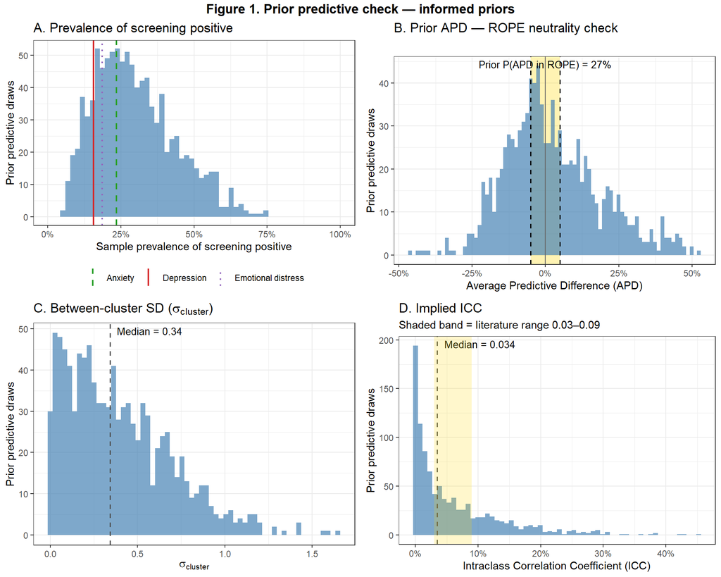

```r
# --- observed endline prevalences for the vertical lines ---
obs_prev <- tibble(
  outcome = c("Depression", "Anxiety", "Emotional distress"),
  prev    = c(mean(endline_clean$depression),
              mean(endline_clean$anxiety),
              mean(endline_clean$emotion))
)

# --- Panel A: Prevalence ---
p_prev <- ggplot(ppc_draws, aes(x = prev)) +
  geom_histogram(bins = 60, fill = "steelblue", alpha = 0.7, color = NA) +
  geom_vline(data = obs_prev,
             aes(xintercept = prev, linetype = outcome, color = outcome),
             linewidth = 0.8) +
  scale_x_continuous(labels = scales::percent_format(accuracy = 1),
                     limits = c(0, 1)) +
  scale_color_manual(values = c("Depression"         = "#d62728",
                                "Anxiety"            = "#2ca02c",
                                "Emotional distress" = "#9467bd")) +
  scale_linetype_manual(values = c("Depression"         = "solid",
                                   "Anxiety"            = "dashed",
                                   "Emotional distress" = "dotted")) +
  labs(x = "Sample prevalence of screening positive",
       y = "Prior predictive draws",
       color = NULL, linetype = NULL,
       title = "A. Prevalence of screening positive") +
  theme_bw(base_size = 11) +
  theme(legend.position = "bottom")

# --- Panel B: APD ---
rope_prob <- mean(abs(ppc_draws$apd) < 0.05)

p_apd <- ggplot(ppc_draws, aes(x = apd)) +
  annotate("rect", xmin = -0.05, xmax = 0.05,
           ymin = -Inf, ymax = Inf, fill = "gold", alpha = 0.3) +
  geom_histogram(bins = 80, fill = "steelblue", alpha = 0.7, color = NA) +
  geom_vline(xintercept = c(-0.05, 0.05),
             linetype = "dashed", linewidth = 0.7) +
  geom_vline(xintercept = 0,
             linetype = "solid", linewidth = 0.4, color = "grey40") +
  annotate("text", x = 0, y = Inf, vjust = 1.5,
           label = sprintf("Prior P(APD in ROPE) = %.0f%%", rope_prob * 100),
           size = 3.5) +
  scale_x_continuous(labels = scales::percent_format(accuracy = 1)) +
  labs(x = "Average Predictive Difference (APD)",
       y = "Prior predictive draws",
       title = "B. Prior APD — ROPE neutrality check",
       subtitle = "Shaded band = ROPE [−0.05, +0.05]") +
  theme_bw(base_size = 11)

# --- Panel C: sigma_cluster ---
p_sigma <- ggplot(ppc_draws, aes(x = sigma)) +
  geom_histogram(bins = 60, fill = "steelblue", alpha = 0.7, color = NA) +
  geom_vline(xintercept = median(ppc_draws$sigma),
             linetype = "dashed", color = "grey30", linewidth = 0.7) +
  annotate("text",
           x = median(ppc_draws$sigma), y = Inf,
           hjust = -0.1, vjust = 1.5,
           label = sprintf("Median = %.2f", median(ppc_draws$sigma)),
           size = 3.5) +
  labs(x = expression(sigma[cluster]),
       y = "Prior predictive draws",
       title = expression("C. Between-cluster SD ("*sigma[cluster]*")")) +
  theme_bw(base_size = 11)

# --- Panel D: ICC ---
p_icc <- ggplot(ppc_draws, aes(x = icc)) +
  geom_histogram(bins = 60, fill = "steelblue", alpha = 0.7, color = NA) +
  geom_vline(xintercept = median(ppc_draws$icc),
             linetype = "dashed", color = "grey30", linewidth = 0.7) +
  annotate("text",
           x = median(ppc_draws$icc), y = Inf,
           hjust = -0.1, vjust = 1.5,
           label = sprintf("Median = %.3f", median(ppc_draws$icc)),
           size = 3.5) +
  annotate("rect", xmin = 0.03, xmax = 0.09,
           ymin = -Inf, ymax = Inf, fill = "gold", alpha = 0.2) +
  scale_x_continuous(labels = scales::percent_format(accuracy = 1)) +
  labs(x = "Intraclass Correlation Coefficient (ICC)",
       y = "Prior predictive draws",
       title = "D. Implied ICC",
       subtitle = "Shaded band = literature range 0.03–0.09") +
  theme_bw(base_size = 11)

# --- Combine into one figure ---
gridExtra::grid.arrange(
  p_prev, p_apd, p_sigma, p_icc,
  ncol = 2,
  top = grid::textGrob(
    "Figure 1. Prior predictive check — informed priors",
    gp = grid::gpar(fontsize = 13, fontface = "bold")
  )
)
```

## 4. Model Fitting

```r
n_chains <- 4L
n_adapt  <- 1000L
n_burnin <- 10000L
n_iter   <- 20000L
n_thin   <- 2L

params_primary <- c("beta_trt", "gamma", "mu0", "sigma_cluster", "alpha")
params_ancova  <- c(params_primary, "delta")

fit_jags <- function(model_string, data_list, params, seed_offset = 0L) {
  inits <- lapply(seq_len(n_chains), function(ch) {
    list(.RNG.name = "base::Mersenne-Twister",
         .RNG.seed = 564L + seed_offset + ch)
  })

  m <- jags.model(
    textConnection(model_string),
    data     = data_list,
    inits    = inits,
    n.chains = n_chains,
    n.adapt  = n_adapt,
    quiet    = TRUE
  )

  update(m, n.iter = n_burnin, progress.bar = "none")

  coda.samples(m,
               variable.names = params,
               n.iter         = n_iter,
               thin           = n_thin,
               progress.bar   = "none")
}
```

```r
fit_anxiety    <- fit_jags(model_string_primary, jags_data_anxiety,    params_primary, 0L)
fit_depression <- fit_jags(model_string_primary, jags_data_depression, params_primary, 1L)
fit_emotion    <- fit_jags(model_string_primary, jags_data_emotion,    params_primary, 2L)
```

```r
fit_ancova_anxiety    <- fit_jags(model_string_ancova, jags_data_ancova_anxiety,    params_ancova, 3L)
fit_ancova_depression <- fit_jags(model_string_ancova, jags_data_ancova_depression, params_ancova, 4L)
fit_ancova_emotion    <- fit_jags(model_string_ancova, jags_data_ancova_emotion,    params_ancova, 5L)
```

## LOO comparison

```r
# Pointwise log-likelihood (S x N matrix) for LOO
compute_log_lik <- function(fit, df, outcome_col, bl_col = NULL) {
  samps      <- as.matrix(fit)
  y          <- as.integer(df[[outcome_col]])
  S          <- nrow(samps)
  N          <- nrow(df)
  alpha_mat  <- samps[, paste0("alpha[", df$cluster_id, "]"), drop = FALSE]
  gamma_all  <- cbind(0, samps[, "gamma[2]"], samps[, "gamma[3]"])
  gamma_mat  <- gamma_all[, df$woreda_id, drop = FALSE]
  eta        <- alpha_mat + gamma_mat +
                outer(samps[, "beta_trt"], df$treatment)
  if (!is.null(bl_col))
    eta <- eta + outer(samps[, "delta"], as.integer(df[[bl_col]]))
  p_mat <- plogis(eta)
  matrix(dbinom(rep(y, each = S), 1L, as.vector(p_mat), log = TRUE),
         nrow = S, ncol = N)
}

# Restrict primary model log-likelihood to the 1,468 households in panel_ancova
endline_common <- endline_clean %>%
  filter(hh_id %in% panel_ancova$hh_id)

loo_pri <- list(
  anx = loo(compute_log_lik(fit_anxiety,    endline_common, "anxiety")),
  dep = loo(compute_log_lik(fit_depression, endline_common, "depression")),
  emo = loo(compute_log_lik(fit_emotion,    endline_common, "emotion"))
)

loo_anc <- list(
  anx = loo(compute_log_lik(fit_ancova_anxiety,    panel_ancova, "anxiety",
                             bl_col = "anxiety_bl")),
  dep = loo(compute_log_lik(fit_ancova_depression, panel_ancova, "depression",
                             bl_col = "depression_bl")),
  emo = loo(compute_log_lik(fit_ancova_emotion,    panel_ancova, "emotion",
                             bl_col = "emotion_bl"))
)
```

```r
loo_compare_row <- function(loo_p, loo_a, outcome) {
  comp <- loo_compare(list(primary = loo_p, ancova = loo_a))
  best <- rownames(comp)[1]
  diff <- comp[2, "elpd_diff"]
  se   <- comp[2, "se_diff"]
  tibble(
    Outcome    = outcome,
    ELPD_primary = round(loo_p$estimates["elpd_loo", "Estimate"], 1),
    ELPD_ancova  = round(loo_a$estimates["elpd_loo", "Estimate"], 1),
    ELPD_diff    = round(diff, 2),
    SE_diff      = round(se,   2),
    Favors       = case_when(
      abs(diff) > 2 * se & best == "ancova"  ~ "ANCOVA",
      abs(diff) > 2 * se & best == "primary" ~ "Primary",
      TRUE                                   ~ "Indistinguishable"
    )
  )
}

loo_tbl <- bind_rows(
  loo_compare_row(loo_pri$anx, loo_anc$anx, "Anxiety"),
  loo_compare_row(loo_pri$dep, loo_anc$dep, "Depression"),
  loo_compare_row(loo_pri$emo, loo_anc$emo, "Emotion")
)

loo_tbl %>%
  kable(col.names = c("Outcome", "ELPD primary", "ELPD ANCOVA",
                       "ΔELPD", "SE(Δ)", "Favors"),
        caption = "Table 2. PSIS-LOO comparison on the common 1,468-household subsample.") %>%
  kable_styling(bootstrap_options = "striped", full_width = FALSE)
```

Table 2. PSIS-LOO comparison on the common 1,468-household subsample.

| Outcome | ELPD primary | ELPD ANCOVA | ΔELPD | SE(Δ) | Favors |
| --- | --- | --- | --- | --- | --- |
| Anxiety | -801.7 | -782.6 | -19.08 | 6.27 | ANCOVA |
| Depression | -629.2 | -616.5 | -12.75 | 5.22 | ANCOVA |
| Emotion | -704.2 | -692.0 | -12.17 | 5.15 | ANCOVA |

## 5. MCMC Diagnostics

```r
key_params <- c("beta_trt", "gamma[2]", "gamma[3]", "mu0", "sigma_cluster")

# gelman.diag fails on zero-variance columns (gamma[1] <- 0)
remove_constants <- function(fit) {
  keep <- apply(as.matrix(fit), 2, var) > 0
  mcmc.list(lapply(fit, function(ch)
    mcmc(as.matrix(ch)[, keep, drop = FALSE],
         start = start(ch), end = end(ch), thin = thin(ch))))
}

diag_summary <- function(fit, outcome) {
  fit_c <- remove_constants(fit)
  rhat  <- gelman.diag(fit_c, multivariate = FALSE)$psrf
  ess   <- effectiveSize(fit_c)

  scalar <- tibble(
    Outcome   = outcome,
    Parameter = key_params,
    Rhat      = round(rhat[key_params, 1], 3),
    Rhat_max  = round(rhat[key_params, 2], 3),
    ESS       = as.integer(round(ess[key_params]))
  )

  alpha_idx  <- grep("^alpha\\[", rownames(rhat), value = TRUE)
  alpha_row  <- tibble(
    Outcome   = outcome,
    Parameter = "alpha[1:50]",
    Rhat      = round(median(rhat[alpha_idx, 1]), 3),
    Rhat_max  = round(max(rhat[alpha_idx, 1]),    3),
    ESS       = as.integer(round(median(ess[alpha_idx])))
  )

  bind_rows(scalar, alpha_row)
}

diag_df <- bind_rows(
  diag_summary(fit_ancova_anxiety,    "Anxiety"),
  diag_summary(fit_ancova_depression, "Depression"),
  diag_summary(fit_ancova_emotion,    "Emotion")
)
```

```r
diag_df %>%
  kable(
    col.names = c("Outcome", "Parameter", "R-hat", "R-hat (UCI)", "ESS"),
    caption   = "Table 3. MCMC convergence diagnostics — ANCOVA models."
  ) %>%
  kable_styling(bootstrap_options = "striped", full_width = FALSE, font_size = 10) %>%
  row_spec(which(diag_df$Rhat > 1.01 | diag_df$ESS < 400),
           background = "#fff3cd") %>%
  footnote(
    general = paste(
      "For alpha[1:50], R-hat is the median point estimate and R-hat (UCI) is the maximum",
      "point estimate across the 50 cluster intercepts; ESS is the median.",
      "Rows highlighted in yellow indicate R-hat > 1.01 or ESS < 400."
    ),
    general_title = "Note:",
    footnote_as_chunk = TRUE
  )
```

Table 3. MCMC convergence diagnostics — ANCOVA models.

| Outcome | Parameter | R-hat | R-hat (UCI) | ESS |
| --- | --- | --- | --- | --- |
| Anxiety | beta_trt | 1.005 | 1.016 | 4547 |
| Anxiety | gamma[2] | 1.005 | 1.016 | 5330 |
| Anxiety | gamma[3] | 1.009 | 1.026 | 4275 |
| Anxiety | mu0 | 1.019 | 1.055 | 1423 |
| Anxiety | sigma_cluster | 1.017 | 1.043 | 481 |
| Anxiety | alpha[1:50] | 1.006 | 1.019 | 4682 |
| Depression | beta_trt | 1.001 | 1.004 | 2666 |
| Depression | gamma[2] | 1.001 | 1.004 | 3423 |
| Depression | gamma[3] | 1.002 | 1.005 | 3174 |
| Depression | mu0 | 1.009 | 1.024 | 638 |
| Depression | sigma_cluster | 1.015 | 1.044 | 399 |
| Depression | alpha[1:50] | 1.004 | 1.009 | 1787 |
| Emotion | beta_trt | 1.000 | 1.001 | 2786 |
| Emotion | gamma[2] | 1.001 | 1.002 | 3197 |
| Emotion | gamma[3] | 1.001 | 1.002 | 3015 |
| Emotion | mu0 | 1.002 | 1.006 | 654 |
| Emotion | sigma_cluster | 1.012 | 1.036 | 301 |
| Emotion | alpha[1:50] | 1.002 | 1.006 | 1577 |

Note: For alpha[1:50], R-hat is the median point estimate and R-hat (UCI) is the maximum point estimate across the 50 cluster intercepts; ESS is the median. Rows highlighted in yellow indicate R-hat > 1.01 or ESS < 400.

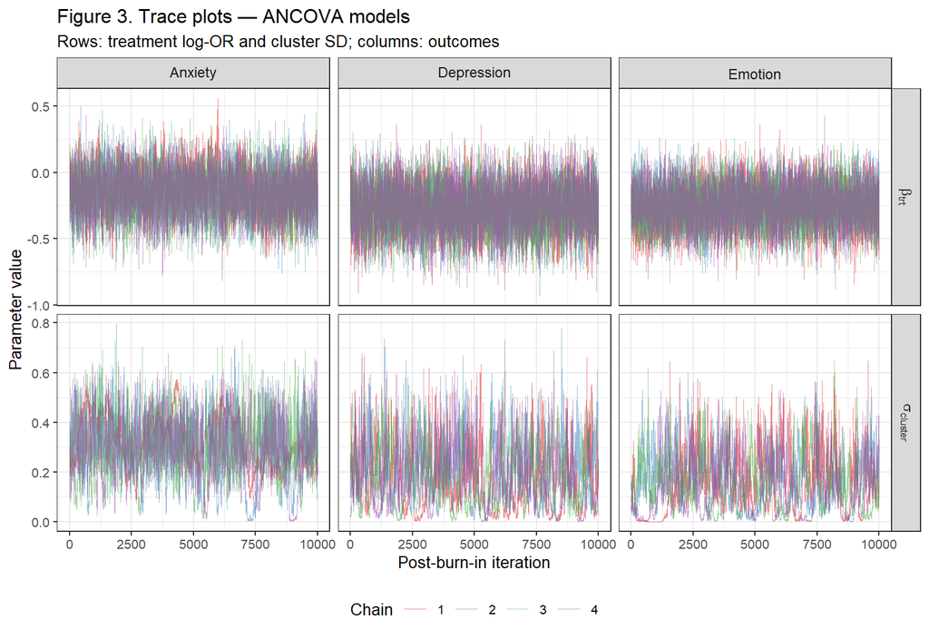

```r
tidy_traces <- function(fit, params, outcome) {
  bind_rows(lapply(seq_along(fit), function(ch) {
    as.data.frame(fit[[ch]]) %>%
      select(all_of(params)) %>%
      mutate(chain = factor(ch), iter = row_number())
  })) %>%
    pivot_longer(all_of(params), names_to = "parameter", values_to = "value") %>%
    mutate(outcome = outcome)
}

trace_df <- bind_rows(
  tidy_traces(fit_ancova_anxiety,    c("beta_trt", "sigma_cluster"), "Anxiety"),
  tidy_traces(fit_ancova_depression, c("beta_trt", "sigma_cluster"), "Depression"),
  tidy_traces(fit_ancova_emotion,    c("beta_trt", "sigma_cluster"), "Emotion")
) %>%
  mutate(
    parameter = recode(parameter,
                       "beta_trt"      = "beta[trt]",
                       "sigma_cluster" = "sigma[cluster]"),
    outcome   = factor(outcome, levels = c("Anxiety", "Depression", "Emotion"))
  )

ggplot(trace_df, aes(x = iter, y = value, color = chain)) +
  geom_line(alpha = 0.5, linewidth = 0.25) +
  facet_grid(parameter ~ outcome, scales = "free_y", labeller = label_parsed) +
  scale_color_brewer(palette = "Set1") +
  labs(
    x        = "Post-burn-in iteration",
    y        = "Parameter value",
    color    = "Chain",
    title    = "Figure 3. Trace plots — ANCOVA models",
    subtitle = "Rows: treatment log-OR and cluster SD; columns: outcomes"
  ) +
  theme_bw(base_size = 10) +
  theme(legend.position = "bottom", strip.text = element_text(size = 9))
```

[figure not shown]

```r
acf_tidy <- function(fit, outcome) {
  bind_rows(lapply(seq_along(fit), function(ch) {
    x   <- as.matrix(fit[[ch]])[, "beta_trt"]
    obj <- acf(x, lag.max = 30, plot = FALSE)
    tibble(lag = as.vector(obj$lag), acf = as.vector(obj$acf),
           chain = factor(ch))
  })) %>% mutate(outcome = outcome)
}

acf_df  <- bind_rows(
  acf_tidy(fit_ancova_anxiety,    "Anxiety"),
  acf_tidy(fit_ancova_depression, "Depression"),
  acf_tidy(fit_ancova_emotion,    "Emotion")
)
ci_line <- qnorm(0.975) / sqrt(5000L)

ggplot(acf_df, aes(x = lag, y = acf, color = chain)) +
  geom_hline(yintercept = c(-ci_line, ci_line),
             linetype = "dashed", color = "grey50") +
  geom_hline(yintercept = 0, color = "grey20", linewidth = 0.3) +
  geom_segment(aes(xend = lag, yend = 0), alpha = 0.7, linewidth = 0.4) +
  facet_wrap(~ outcome, nrow = 1) +
  scale_color_brewer(palette = "Set1") +
  labs(
    x        = "Lag",
    y        = "Autocorrelation",
    color    = "Chain",
    title    = "Figure 4. Autocorrelation of beta_trt — ANCOVA models",
    subtitle = "Dashed lines: 95% CI bounds for zero autocorrelation (n = 5,000)"
  ) +
  theme_bw(base_size = 10) +
  theme(legend.position = "bottom")
```